# circletime

The goal of circletime is to provide tools to model and analyze cyclical biological processes via single-cell RNAseq analysis. To do this, circletime provides a series of tools to generate cyclical pseudotemoral ordering, visualization, and identification of genes associated with progression through the cyclical process.

## Installation

You can install circletime from [GitHub](https://github.com/) with:

```
# install.packages("devtools")
devtools::install_github("arc85/circletime")
```

## Pseudotemporal ordering of a cyclical process

Here, we demonstrate how to generate a cyclical pseudotemporal ordering and to apply that ordering to our low-dimensional embedded data. We are going to utilize two principal components here for simplicity, but this methodology can be applied to other embeddings that meaningful preserve high-dimensional distances (e.g. diffusion maps or UMAPs).

The single-cell expression data used for this demonstration are derived from [Nestorowa et al, Blood 2016](https://pubmed.ncbi.nlm.nih.gov/27365425/). Usage of this dataset was inspired by the Seurat vignette for regressing out cell cycle effects, linked [here](https://satijalab.org/seurat/v3.2/cell_cycle_vignette.html). Please see also the R files in data-raw (or eventually the pkgdown vignette) for a full description of the pre-processing.

## Order cells through cyclical process

```
library(circletime)
library(ggplot2)

#Visualize embedding
ggplot(cycle.small,aes(x=PC_1,y=PC_3,colour=clusters)) +
    geom_point() +
    theme_bw()
```

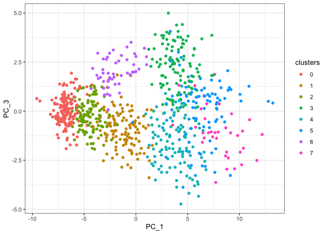

```
#Calculate pseudotime for all cells
small.pseudotime <- calc_pseudotime(embedding=cycle.small[,c(1,3)],clusters=cycle.small$clusters)

head(small.pseudotime)
#>          cell_order pseudotime
#> Prog_013        250  59.493504
#> Prog_019        748  17.876051
#> Prog_031        610  39.393329
#> Prog_037        341  11.759658
#> Prog_008        735   4.939973
#> Prog_014        135  16.084062

#Combine data and visualize pseudotime
cycle.small.pseudotime <- cbind(cycle.small,small.pseudotime)

ggplot(cycle.small.pseudotime,aes(x=PC_1,y=PC_3,colour=pseudotime)) +
    geom_point() +
    theme_bw()
```

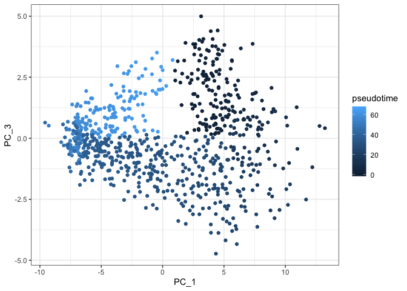

## Map progression through pseudotime

It can be useful to visualize the progression through the cyclical process. We demonstrate here how to easily do this using `order_clusters_by_time`.

```
temporal.ordered.clusters <- order_clusters_by_time(embedding=cycle.small.pseudotime[,c(1,3)],clusters=cycle.small.pseudotime$clusters,pseudotime=cycle.small.pseudotime$pseudotime)

#Convert previous clusters to temporally ordered clusters
level.key <- temporal.ordered.clusters$new_cluster_id
names(level.key) <- temporal.ordered.clusters$clusters

cycle.small.pseudotime$ordered.clusters <- dplyr::recode(cycle.small.pseudotime$clusters,!!!level.key)

cycle.small.pseudotime$ordered.clusters <- as.factor(cycle.small.pseudotime$ordered.clusters)

#Visualize progression
ggplot() +
    geom_point(data=cycle.small.pseudotime,aes(x=PC_1,y=PC_3,colour=ordered.clusters)) +
  geom_point(data=temporal.ordered.clusters,aes(x=PC_1_mean,y=PC_3_mean),size=2) +
  geom_path(data=temporal.ordered.clusters,aes(x=PC_1_mean,y=PC_3_mean)) +
    theme_bw()
```

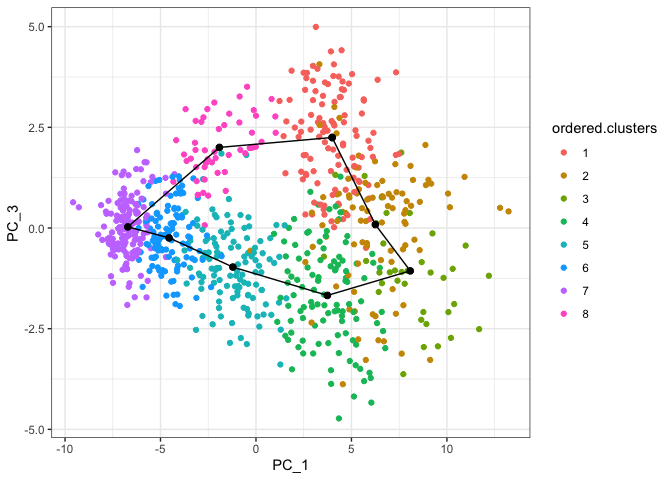

## Identify genes associated with cyclical process

We can use generalized additive models to evaluate whether genes are temporally associated with the pseudotemporal process.

```
temporal.genes <- genes_over_time(expr.matrix=genes.small,pseudotime=cycle.small.pseudotime$pseudotime)
#> Loading required package: Matrix

#View names of output list
names(temporal.genes)
#> [1] "expression_fits" "p_values"
names(temporal.genes[[1]])[1:10]
#>  [1] "CCNB2"         "HIST1H2BC"     "CTSG"          "ELANE"
#>  [5] "MPO"           "F630028O10RIK" "IGSF6"         "PRTN3"
#>  [9] "MS4A3"         "LY6C2"

#Bind fit modules into data.frame
fits.frame <- t(do.call(rbind,temporal.genes[[1]]))
fits.frame <- data.frame(fits.frame)

#View genes by temporal dynamics
par(cex=0.8)
plot(hclust(dist(t(fits.frame))),xlab="",ylab="",main="",sub="",axes=FALSE)
```

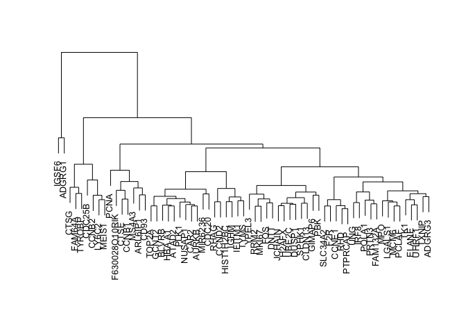

```
pheatmap::pheatmap(t(fits.frame),scale="row",show_colnames=FALSE,fontsize=6)
```

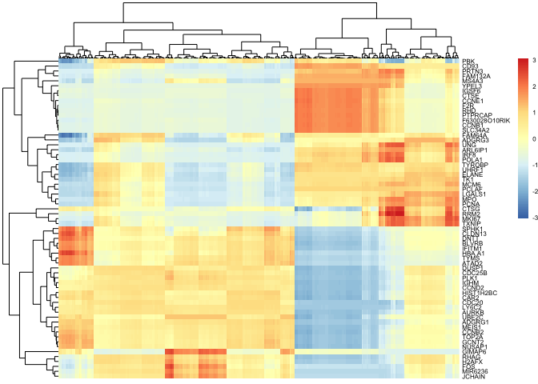

```
#Add pseudotime to data.frame
fits.frame.time <- fits.frame
fits.frame.time$pseudotime <- cycle.small.pseudotime$pseudotime

#Order gene expression by pseudotime
fits.frames.dynamics <- fits.frame.time[,c("PBK","TXNIP","CLDN13","pseudotime")]
fits.frames.dynamics <- fits.frames.dynamics[order(fits.frames.dynamics$pseudotime),]

#Remove pseudotime and melt for plotting
fits.frames.dynamics <- fits.frames.dynamics[,-which(colnames(fits.frames.dynamics)=="pseudotime")]
fits.frames.dynamics <- apply(fits.frames.dynamics,2,scale)
fits.frames.dynamics <- reshape2::melt(fits.frames.dynamics)

colnames(fits.frames.dynamics) <- c("Pseudotime","Gene","Expression")

#Visuale gene dynamics over time
ggplot(fits.frames.dynamics,aes(x=Pseudotime,y=Expression,group=Gene,colour=Gene)) +
  geom_line(size=2) +
  theme_bw()
```

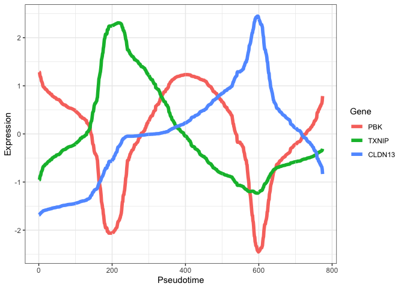